# Microeconometrics (Causal Inference) Week 9 - Regression discontinuity

Joshua D. Merfeld KDI School of Public Policy and Management

2023-11-13

## What are we doing today?

- Regression discontinuity
  - Requirements/assumptions
- Sharp and fuzzy RD
  - IVs and RDs

## Motivation - standardized tests (fictitious data)

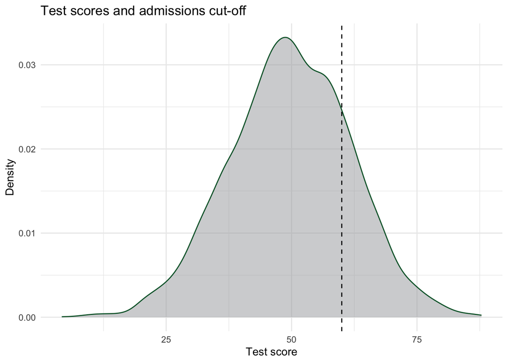

## Motivation - standardized tests

- In our example, you get into college if you score 60 or higher on a standardized test
- On average, “smarter” (in a broad sense) students will score higher on the test
- However, there is a lot of variation in scores among students with similar “smartness”
  - If one of us took the test multiple times, we’d probably get slightly different scores each time
  - We each have our own “distribution”
  - On a given day, how well (or not) we do is somewhat random

## Motivation - standardized tests

- Continuing with the example, imagine all of the students around the cut-off score of 60
- On average, students just below and just above the cut-off score are similar
  - They have similar “smartness”
  - They should also be similar on other variables!
- This is especially true if the test is a one-off test that you can’t retake
  - Or if we don’t know what the cut-off is
  - If we know the cut-off is 60 *and* we can take the test multiple times, what might we do?

## Returns to college - RD example, two possibilities

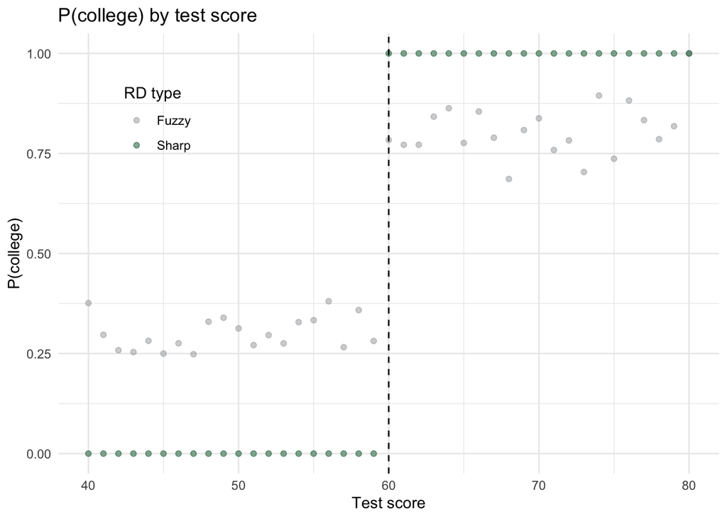

## Returns to college - RD example

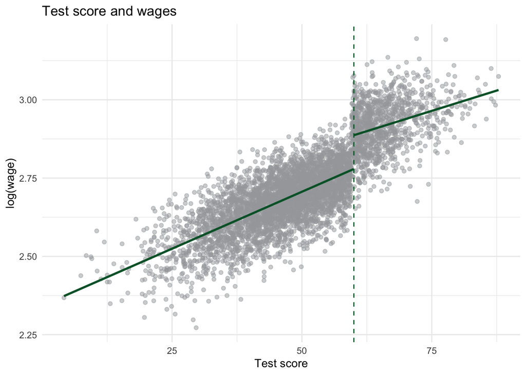

## Regression discontinuity assumptions

- RD only works in a very specific context: when there is a clear cut-off in some variable (called the running variable) that determines treatment
- The best-case scenario is something we already discussed:
  - People don’t know the cut-off at the time
  - The cut-off is not something you can manipulate (for example if you can only take a test once)
- In these cases, we can assume that people just above and just below the cut-off are similar
  - Implication: they should be similar on variables unaffected by treatment
    - We can check this!
  - Implication: density on either side of the cut-off should be similar
    - We can check this!

## Example: Bleemer and Mehta

- Bleemer and Mehta (2022): Will studying economics make you rich? A regression discontinuity analysis of the returns to college major
  - *AEJ: Applied*
- Note: The data is confidential, so we can’t replicate the results
  - We’ll just go through the paper and discuss
- We’ll replicate a common RD design later

## Background for Bleemer and Mehta

- Data from UC Santa Cruz
  - Public university
- Starting in 2003, the econ department instituted a GPA restriction
  - Common for majors that are oversubscribed
  - Students with a GPA below 2.8 were not allowed to declare an econ major
    - (It’s a little more complicated than that, but we’ll just go with this for)
- Originally, grades in Economics 1 and 2 were counted
  - Added calculus in 2013

## Data

- They have information on individual students from their time in school
  - Information on econ GPA (EGPA) as well as other grades
  - Gender, ethnicity, cohort year, home address, residency status, high school, and SAT score
- They link the data to employment records from the California Employment Development Department
  - Annual wages and six-digit industry (NAICS) code
- You can probably tell by now why the data is confidential

## Estimating RD empirically

- Graphs are nice, but we want to estimate the effect of majoring in economics on earnings
- Simplest specification:
  $$\begin{gather} \label{eq:rd} y_{it} = \alpha_0 +
  \alpha_1 EGPA + \alpha_2 \mathbb{I}(EGPA \geq 2.8) + \alpha_3
  \mathbb{I}(EGPA \geq 2.8)\times EGPA + \epsilon_{it}
  \end{gather}$$
- $EGPA$ is the student’s econ GPA
- $\mathbb{I}(EGPA \geq 2.8)$ is an indicator for whether the student had a GPA high enough to declare an econ major
- We are allowing the effect of EGPA to be different for students above and below the cut-off
- Usually first check the intermediate outcome (econ major) and then final outcome (wages)

## With our fictitious data - test score and wages

```
## OLS estimation, Dep. Var.: log(wages)
## Observations: 5,000
## Standard-errors: Heteroskedasticity-robust
##                         Estimate Std. Error   t value   Pr(>|t|)
## (Intercept)             2.342778   0.005999 390.54222  < 2.2e-16 ***
## scores                  0.007271   0.000128  56.85130  < 2.2e-16 ***
## I(scores >= 60)         0.233236   0.028469   8.19254 3.2192e-16 ***
## scores:I(scores >= 60) -0.002090   0.000434  -4.81940 1.4826e-06 ***
## ---
## Signif. codes:  0 '***' 0.001 '**' 0.01 '*' 0.05 '.' 0.1 ' ' 1
## RMSE: 0.072836   Adj. R2: 0.718956
```

## With our fictitious data - test score and wages

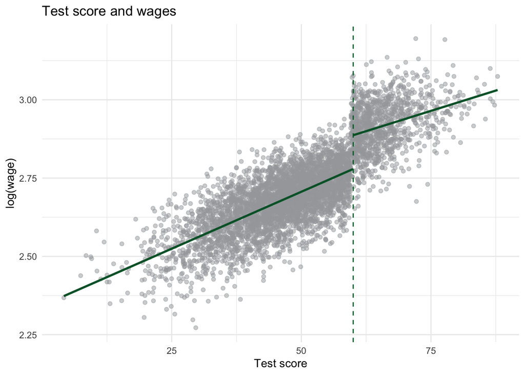